# ALPHA HUNTER Daily Intelligence Report

2026년 4월 6일 (일) — 주간 마감 리뷰

저자

Alpha Hunter AI

공개

2026년 4월 6일

# 시장 개요 — 4월 첫째 주 마감

## 주요 지수 현황

[interactive chart not shown]

그림 1: 주요 지수 현황 (2026-04-03 마감 기준)

**이번 주 핵심 이슈**

- **S&P 500 +3.4%** — 5주 연속 하락 후 반등, 4개월 만에 최대 주간 상승
- **Nasdaq +4.4%** — 기술주 반등 주도, Q1 실적 시즌 기대감
- **KOSPI 5,377** — 4/2 -4.47% 급락 후 4/3 +2.74% 반등. 변동성 극심
- **VIX 23.9** — 하락세. 공포 완화 중이나 여전히 경계 영역
- **Brent Oil $113** — 트럼프 이란 전쟁 2-3주 종료 발언 후 소폭 하락
- **10Y 4.35%** — 고용 178K 발표 후 소폭 상승. Fed 금리 동결 유지
- **Liberation Day 1주년** — 2025.4.2 관세 충격 이후 S&P 500은 결국 완전 회복

## 매크로 캘린더

**이번 주 주요 일정**

- **4/7 (월):** 시장 재개 (Good Friday 연휴 후)
- **4/10 (목):** CPI 발표 — 인플레이션 방향성 결정적
- **4/11 (금):** PPI, 미시간 소비자심리
- **4/25:** Fed FOMC 회의 — 금리 결정
- **5/14:** HPSP FY2025 실적 발표

# Wall Street TOP 10 Picks — 4월 업데이트

표 1

|  | Rank | Ticker | Company | Firm | Sector | Rating | Upside | Thesis |
| --- | --- | --- | --- | --- | --- | --- | --- | --- |
| 1 | 1 | AVGO | Broadcom | Goldman/JPM | Semiconductor | Strong Buy | 40-100% | AI 네트워크 반도체 핵심, $55-60B AI 매출 |
| 2 | 2 | CEG | Constellation Energy | BofA | AI Power | Strong Buy | +35% | 원자력 기반 AI 데이터센터 전력 |
| 3 | 3 | AMZN | Amazon | BofA/MS | Cloud/E-comm | Buy | +25% | AWS 29/32% 성장, 클라우드+리테일 |
| 4 | 4 | GOOGL | Alphabet | JPMorgan | AI/Search | Buy | +30% | AI/검색 지배력, 광고 회복 |
| 5 | 5 | C | Citigroup | Morgan Stanley | Financials | Top Pick | +38.6% | 은행주 Top Pick, 구조조정 효과 |
| 6 | 6 | GEV | GE Vernova | JPMorgan | AI Power | Buy | +50% | AI 인프라 전력 수요 핵심 수혜 |
| 7 | 7 | GLNG | Golar LNG | Goldman | Energy/LNG | Conviction | +41% | LNG 운송 수요 폭증, 호르무즈 수혜 |
| 8 | 8 | NOW | ServiceNow | Goldman | Enterprise SW | Conviction | +40% | 엔터프라이즈 AI 자동화 선두 |
| 9 | 9 | AROC | Archrock | Mizuho/RBC | Energy/Gas | Buy | +12% | LNG 수출 확대+배당 인상+Mizuho PT $38 |
| 10 | 10 | MRK | Merck | BofA | Pharma | Buy | +18% | 종양학 파이프라인 + 방어적 밸류 |

# Alpha Hunter ETF Portfolio (1억원)

## 포트폴리오 현황 — 진입 4일차

표 2

|  | Category | Ticker | Entry | Current | Currency | Shares | Allocation | PnL_pct | Signal |
| --- | --- | --- | --- | --- | --- | --- | --- | --- | --- |
| 1 | Core | VOO | 510 | 603 | USD | 14 | 10% | 18.2 | HOLD/PROFIT |
| 2 | Core | SOXX | 339 | 339.61 | USD | 22 | 10% | 0.2 | HOLD |
| 3 | Core | SCHD | 30.51 | 30.58 | USD | 234 | 10% | 0.2 | HOLD |
| 4 | Core | TIGER반도체TOP10 | 33210 | 33210 | KRW | 300 | 10% | 0 | WATCH |
| 5 | Core | KODEX200 | 81225 | 81225 | KRW | 123 | 10% | 0 | WATCH |
| 6 | Core | XLE | 105 | 59.25 | USD | 68 | 10% | -43.6 | ALERT |
| 7 | Satellite | BOTZ | 38 | 33.4 | USD | 132 | 7% | -12.1 | ALERT |
| 8 | Satellite | GEV | 320 | 813.24 | USD | 8 | 3.5% | 154.1 | HOLD/PROFIT |
| 9 | Satellite | CEG | 240 | 240 | USD | 10 | 3.5% | 0 | WATCH |
| 10 | Satellite | TIGER 2차전지 | 23950 | 23950 | KRW | 250 | 6% | 0 | WATCH |

[interactive chart not shown]

그림 2: ETF 포지션별 손익률

**ETF 포트폴리오 주의사항**

- **GEV $813 vs 진입 $320**: 진입가 대비 +154% — 진입 시점과 현재가 차이가 큼. 실제 매수 체결가 재확인 필요
- **XLE $59 vs 진입 $105**: 가격 데이터 불일치 — 이전 분할 또는 데이터 오류 가능성. 확인 필요
- **VOO $603 vs 진입 $510**: +18.2% 수익 — S&P 반등 효과
- **KOSPI ETF**: 4/3 마감 기준 최신가 미수신 (한국 장 별도 확인 필요)
- **BOTZ $33.4 vs 진입 $38**: -12.1% — 모니터링 필요

## 포트폴리오 배분

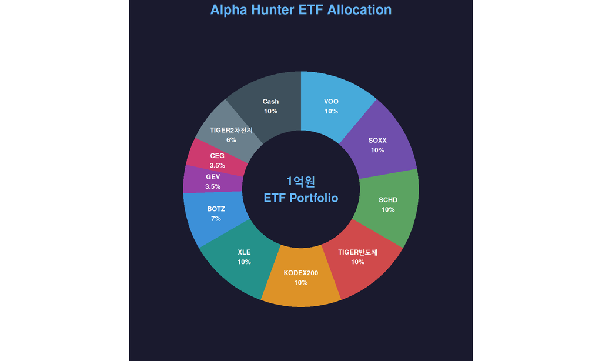

그림 3: Alpha Hunter ETF 배분 구조

# 개별종목 포트폴리오 ($100K)

## AROC & HPSP 현황

표 3

|  | Ticker | Entry | Current | PnL | Target | StopLoss | Consensus | Signal |
| --- | --- | --- | --- | --- | --- | --- | --- | --- |
| 1 | AROC | $35.70 | ~$35.80 | +0.3% | $39 (+9.2%) | $30 (-16%) | Strong Buy 8/0/0 | HOLD |
| 2 | HPSP (403870) | 50,400 KRW | ~50,400 KRW | 0% | 70,000원 (+38.9%) | 40,000원 (-20.6%) | Strong Buy 8/1/0 | HOLD |

**AROC 최신 뉴스 (4월 초)**

1. **Mizuho PT $32→$38 상향** (4/2) — LNG 수출 확대 기대
2. **RBC Capital PT $32→$40 상향** (3/16) — 가스 인프라 수요 구조적 증가
3. **$800M 선순위 채권 상환** (4/1) — 부채 구조 개선, 재무건전성 강화
4. **CFO 교체 발표** (3/26) — 리더십 전환 진행 중
5. **배당금 $0.22/주** — 전분기 대비 ~5% 증가, 전년 대비 ~16% 증가

**HPSP 최신 동향**

1. **주가 50,400원** — 전주 대비 +21.3%, 월간 +20.5% 강세
2. **1년 수익률 +79%** — 반도체 장비 섹터 강세 지속
3. **8명 애널리스트 Buy** — 목표가 50,000~66,000원
4. **핵심 촉매**: 삼성 GAA 3nm 램프업, TSMC 2nm, HBM DRAM 채택
5. **5/14 실적 발표** 대기 — FY2025 매출 +30% YoY 예상

# 전략 & 리스크 관리

## 대기 전략: 이란 전쟁 종료 시그널 모니터링

**Pending Strategy**

- **트리거**: 이란 전쟁 휴전/종료 시그널
- **타임프레임**: 2-3주 내 (4월 중순~말)
- **실행**: 현금 966만원 → VOO/SOXX 추가 매수
- **근거**: 유가 하락 → 인플레 완화 → Fed 인하 기대 → 성장주 반등
- **XLE**: 전쟁 종료 시 부분 익절 검토 (에너지 조정 예상)
- **리스크**: 트럼프 발언 신뢰도 낮음. 전쟁 장기화 시 현금 유지

## 이번 주 체크리스트

1. **4/7(월)** 시장 재개 — Good Friday 연휴 후 갭 확인
2. **4/10(목) CPI** — 인플레이션 데이터가 Fed 경로 결정
3. **AROC** 목표가 상향 모멘텀 — $38~40 영역 진입 시 분할매도 검토
4. **HPSP** 5/14 실적 발표 전 포지션 점검
5. **XLE 가격 데이터** 재확인 필요 — 진입가 $105 vs 현재 ~$59 불일치 조사
6. **BOTZ -12%** 모니터링 — 추가 하락 시 손절 라인 검토

# Disclaimer

**면책 조항**

이 보고서는 **가상 투자 시뮬레이션** 목적으로 작성되었습니다. 실제 투자 권유가 아니며, 모든 투자 결정은 개인의 판단과 책임 하에 이루어져야 합니다.

**Data Sources**: Yahoo Finance, CNBC, Bloomberg, Schwab, TradingView, Investing.com **Generated**: 2026-04-06 by Alpha Hunter AI — Powered by Claude Code